# MScA, Statistical Analysis (31007) Week 2: Workshop

Yuri Balasanov,© iLykei 2016

# 1 Simulation of random variables using distribution function and inverse distribution function

Plot the following graph and explain:

1. How normal observations get transformed into uniform observations?
2. How uniform observations get transformed into normal observations?

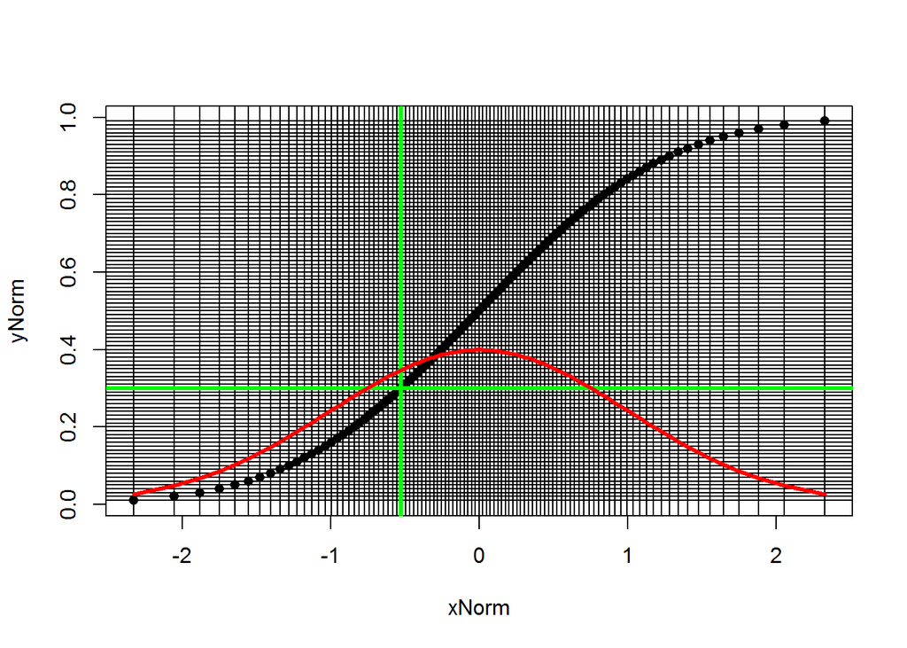

```r
xNorm<-qnorm((1:99)/100)
yNorm<-pnorm(xNorm)
plot(xNorm,yNorm,pch=16)
abline(h=yNorm)
abline(v=xNorm)
abline(h=yNorm[30],col="green",lwd=3)
abline(v=xNorm[30],col="green",lwd=3)
lines(xNorm,dnorm(xNorm),lwd=3,col="red")
```

Answer the same questions for exponential observations instead of normal observations

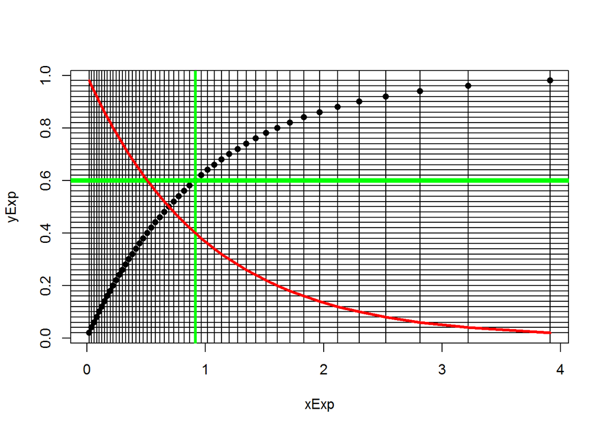

```r
xExp<-qexp((1:49)/50)
yExp<-pexp(xExp)
plot(xExp,yExp,pch=16)
abline(h=yExp)
abline(v=xExp)
abline(h=yExp[30],col="green",lwd=5)
abline(v=xExp[30],col="green",lwd=3)
lines(xExp,dexp(xExp),lwd=3,col="red")
```

# 2 Runs test

A run of a sequence is a non-empty segment of the sequence consisting of adjacent equal elements.  
For example, the following sequence:

```r
set.seed(19)
(x<-sample(c(1,2),10,replace=T))
```

```
##  [1] 1 1 2 1 1 1 1 2 2 2
```

Has runs: 2 of 1s, 1 of 2s, 4 of 1s, 3 of 2s.

Calculate number and lengths of runs.

```r
(diffs <- x[-1] != x[-length(x)])
```

```
## [1] FALSE  TRUE  TRUE FALSE FALSE FALSE  TRUE FALSE FALSE
```

```r
rbind(x[-1],x[-length(x)],diffs*1) # explain diffs
```

```
##      [,1] [,2] [,3] [,4] [,5] [,6] [,7] [,8] [,9]
## [1,]    1    2    1    1    1    1    2    2    2
## [2,]    1    1    2    1    1    1    1    2    2
## [3,]    0    1    1    0    0    0    1    0    0
```

```r
idx <- c(which(diffs), length(x)) # which(diffs) returns positions where logical vector equals T
(Runs<-diff(c(0, idx)))
```

```
## [1] 2 1 4 3
```

Check the identified runs:

```r
x        # sequence
```

```
##  [1] 1 1 2 1 1 1 1 2 2 2
```

```r
x[1:2]   # run 1
```

```
## [1] 1 1
```

```r
x[3]     # run 2
```

```
## [1] 2
```

```r
x[4:7]   # run 3
```

```
## [1] 1 1 1 1
```

```r
x[8:10]  # run 4
```

```
## [1] 2 2 2
```

Alternatively number of runs can be found by `rle()`.

```r
rle(x)
```

```
## Run Length Encoding
##   lengths: int [1:4] 2 1 4 3
##   values : num [1:4] 1 2 1 2
```

Under the null hypothesis, the number of runs in a sequence of $N$ elements is a random variable with conditional distribution given the observation of $N_1$ 1s and $N_2$ 2s, $N = N_1 + N_2$ is approximately normal, with:
$$\mu=\frac{2N_1N_2}{N}+1$$
$$\sigma=\frac{2N_1N_2(2N_1N_2-N)}{N^2(N-1)}=\frac{(\mu-1)(\mu-2)}{N-1}$$
The assumption of null hypothesis is that numbers are independent and identically distributed.

```r
library(randtests)
```

```r
runsTest<-runs.test(x,threshold=1.5)
runsTest
```

```
##
##  Runs Test
##
## data:  x
## statistic = -1.2644, runs = 4, n1 = 4, n2 = 6, n = 10, p-value =
## 0.2061
## alternative hypothesis: nonrandomness
```

```r
runsTest$mu
```

```
## [1] 5.8
```

```r
runsTest$var
```

```
## [1] 2.026667
```

```r
runsTest$runs
```

```
## [1] 4
```

Check how far the observed number of runs is from the theoretical value.

```r
(deviation<-(runsTest$runs-runsTest$mu)/sqrt(runsTest$var))
```

```
## [1] -1.264391
```

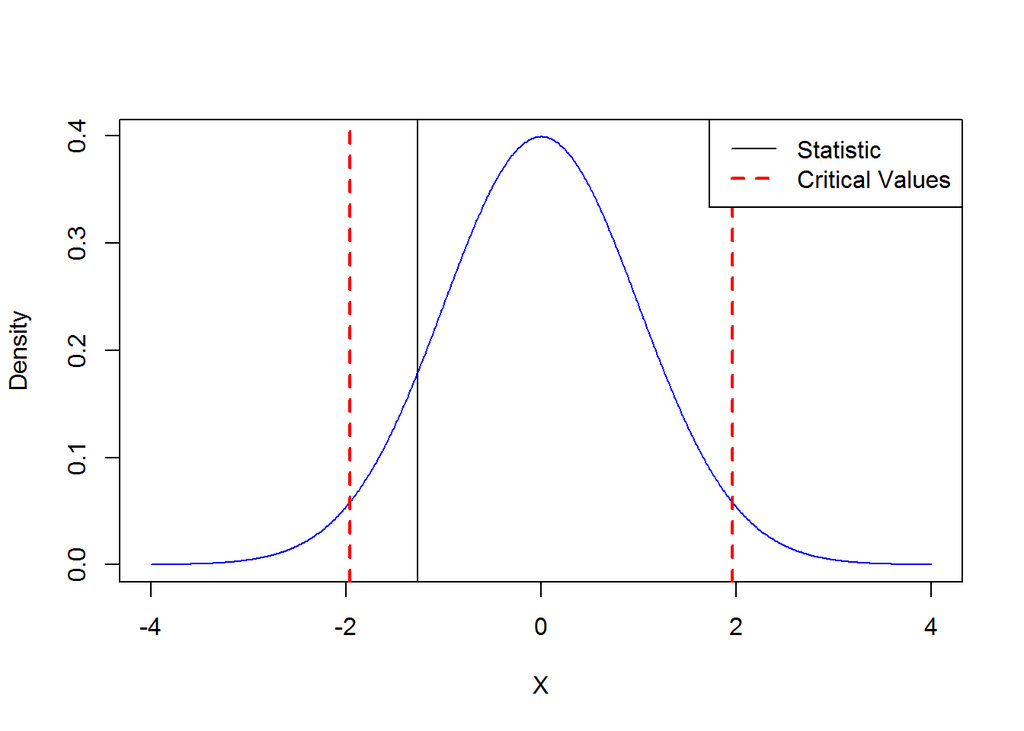

```r
plotX<-seq(from=-4,to=4,by=.01)
plot(plotX,dnorm(plotX),type="l",col="blue",xlab="X",ylab="Density")
abline(v=deviation)
abline(v=qnorm(.025),col="red",lty=2,lwd=2)
abline(v=qnorm(.975),col="red",lty=2,lwd=2)
legend("topright",legend=(c("Statistic","Critical Values")),col=c("black","red"),lty=c(1,2),lwd=c(1,2))
```

Make a sample of 10 values of 1s and 2s for which the test hypothesis is rejected.

(Skipped Code)

```r
badRunsTest<-runs.test(badSample,threshold=1.5)
(deviation<-(badRunsTest$runs-badRunsTest$mu)/sqrt(badRunsTest$var))
```

```
## [1] -2.66927
```

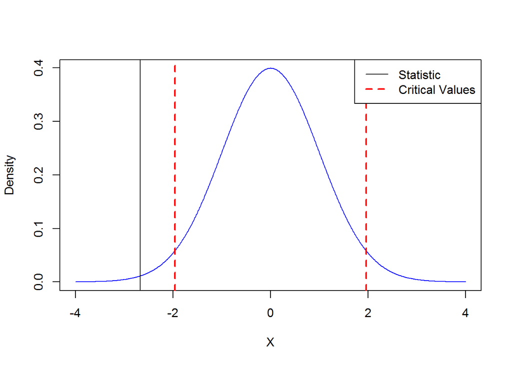

```r
plotX<-seq(from=-4,to=4,by=.01)
plot(plotX,dnorm(plotX),type="l",col="blue",xlab="X",ylab="Density")
abline(v=deviation)
abline(v=qnorm(.025),col="red",lty=2,lwd=2)
abline(v=qnorm(.975),col="red",lty=2,lwd=2)
legend("topright",legend=(c("Statistic","Critical Values")),col=c("black","red"),lty=c(1,2),lwd=c(1,2))
```

# 3 Simulate Linear Model

Recall Method of simulation of linear model.

In order to simulate linear model
$$Y = aX + b + \epsilon, a=1, b=2.5:$$

1. Set parameters `a` and `b`.

```r
a<-1;
b<-2.5
```

Set the sample length.

```r
nSample<-500
```

2. Then simulate $\epsilon_i$ as independent identically distributed (i.i.d.) normal random variables with $\mu = 0, \sigma =1.5$. The variable name for $\epsilon$ is `Eps`.  
   **Hint:** use function `rnorm()` Put `set.seed(8402)` command in each chunk of code in your `.Rmd` file to make reproducible results.

(Skipped Code)

Show head of `Eps`:

```r
head(Eps)
```

```
## [1] -1.8297969 -0.1862884  1.4219400 -1.0841421 -1.5276701  1.6159368
```

3. Simulate the predictor variable $X$ i.i.d. random variables $X_i, i=1, \ldots, nSample,$ from the distribution specified in cases Model 1 and Model 2.
4. Create the output variable $Y_i, i=1, \ldots, nSample$ as
   $$Y_i = aX_i + b + \epsilon_i.$$

```r
Y <- a* X + b + Eps
```

5. Create the table with the model data:

```r
Model<-as.data.frame(cbind(Y=Y,X=X))
```

## 3.1 Model 1.

Simulate `Model1` with the predictor $X_i,i=1, \ldots, nSample$ distributed as i.i.d. normal random variables with $\mu=3, \sigma=2.5$.  
Make `Model1` a data frame with variables `X` and `Y`.

Use `set.seed(8402)`.

(Skipped Code)

Print head of the data frame `Model1` and plot $X$ against $Y$

```r
head(Model1)
```

```
##           Y           X
## 1 0.6205415 -0.04966158
## 2 5.0032309  2.68951931
## 3 9.2918401  5.36990007
## 4 2.6089543  1.19309646
## 5 1.4262132  0.45388323
## 6 9.8091647  5.69322795
```

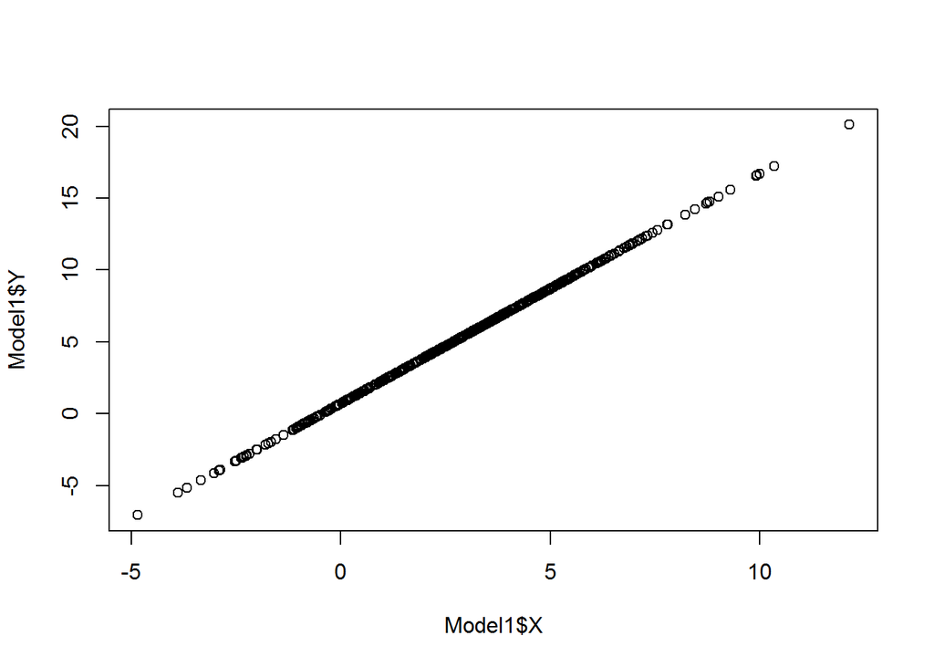

```r
plot(Model1$X,Model1$Y)
```

**What is wrong with the picture?**

Use a different seed for simulation of `X`: 2048.

(Skipped Code)

```r
head(Model1)
```

```
##          Y         X
## 1 1.562262 0.8920591
## 2 4.422258 2.1085467
## 3 6.044722 2.1227820
## 4 5.101608 3.6857499
## 5 5.283881 4.3115510
## 6 6.046797 1.9308605
```

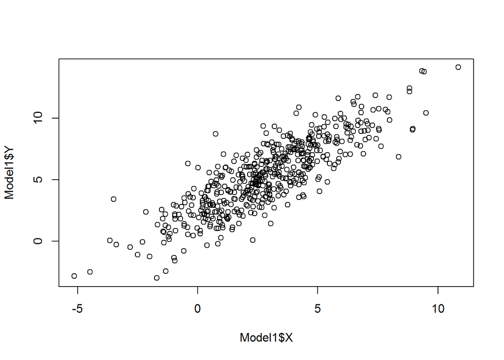

```r
plot(Model1$X,Model1$Y)
```

## 3.2 Model 2.

Simulate `Model2` with the predictor $X_i,i=1, \ldots, nSample$ distributed as i.i.d. exponential random variables with $\lambda=0.5$.

(Skipped Code)

Print the head of data frame `Model2` and plot $X$ against $Y$.

```r
head(Model2)
```

```
##           X        Eps         Y
## 1 3.9656271 -1.8297969  4.635830
## 2 0.5000400 -0.1862884  2.813752
## 3 6.3886953  1.4219400 10.310635
## 4 0.4322918 -1.0841421  1.848150
## 5 1.1109646 -1.5276701  2.083295
## 6 0.8003058  1.6159368  4.916243
```

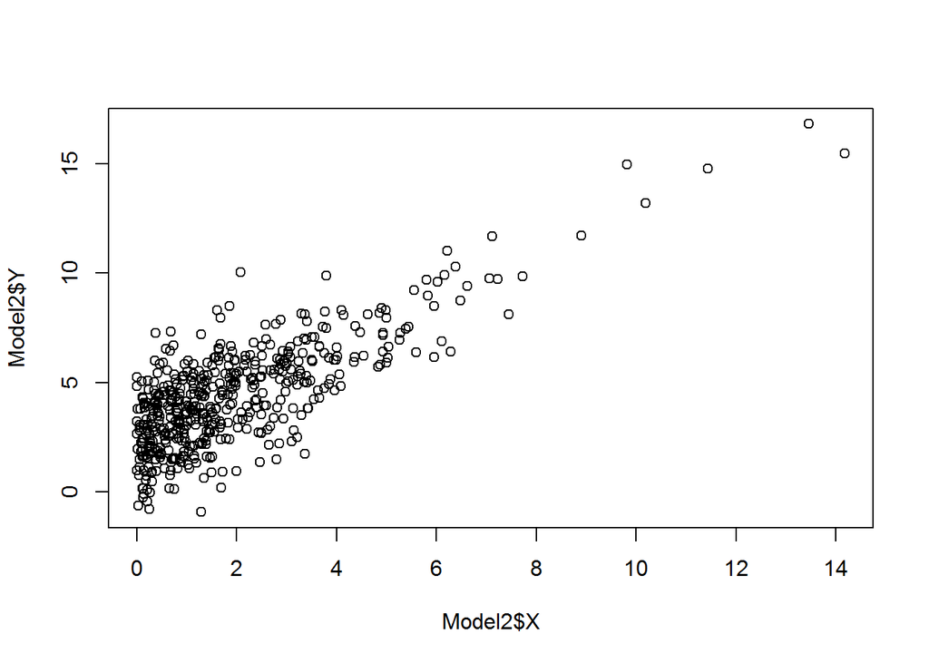

```r
plot(Model2$X,Model2$Y)
```